# Manim Talk 1

UWAGGS

2024-11-07

# What is Manim

https://docs.manim.community/en/stable/index.html#

Manim is a free library in Python developed by 3blue1brown (Grant Sanderson) that allows you make images and animations of mathematical and musical concepts.

It hasn’t been used very much in sports analytics yet, but there’s a lot of potential.

[figure not shown]

```
from manim import *
```

# Installation

https://docs.manim.community/en/stable/installation.html

The following options are avialable for ManimCE (Manim Community Edition)

- Installing Manim to a conda environment
- Installing Manim to your system’s Python
- Using Manim via Docker
- Interactive Jupyter notebooks via Binder / Google Colab

(I did all this with Jupyter notebooks and saving images and animations)

# Example 1: Points on a line

Let’s start by rendering some `Dot`s in `[x,y,z]` space.

From: https://docs.manim.community/en/stable/examples.html

```
class Dots(Scene):
    def construct(self):
        dot = Dot([-2, -1, 0])
        dot2 = Dot([2, 1, 0])
        self.add(dot, dot2)

# don't remove below command for run button to work
%manim -qm -v WARNING Dots
```

# Example 1: Points on a line

Let’s break down this code:

```
class Dots(Scene):
    def construct(self):
        dot = Dot([-2, -1, 0])
        dot2 = Dot([2, 1, 0])
        self.add(dot, dot2)

# don't remove below command for run button to work
%manim -qm -v WARNING Dots
```

First, we are creating a `Scene`, and naming it `Dots`.

```
class Dots(Scene):
```

Which we are defining by the following construction

```
def construct(self):
```

Make two elements of type `Dot` and define their parameters. In this case, those parameters are just [x,y,z] coordinates.

These elements are called Mobjects, short for Math Objects.

```
dot = Dot([-2, -1, 0])
dot2 = Dot([2, 1, 0])
```

Add these two dots that you defined to the scene. Note that you do NOT need to add every Mobject to the scene. If you don’t, Mobject is still defined and can be referred to by other Mobjects, but it won’t render in the scene.

```
self.add(dot, dot2)
```

This last line is only needed when you’re working in an interactive environment like a Jupyter notebook. Without it, the code won’t run. It’s always `%manim -qm -v WARNING SCENENAME`. In this case `SCENENAME` is `Dots`.

```
# don't remove below command for run button to work
%manim -qm -v WARNING Dots
```

# Example 1: Points on a line

From: https://docs.manim.community/en/stable/examples.html

```
class Dots(Scene):
    def construct(self):
        dot = Dot([-20, -10, 0])
        dot2 = Dot([20, 10, 0])
        dot3 = Dot([0, 0, 0])
        self.add(dot, dot2, dot3)

# don't remove below command for run button to work
%manim -qm -v WARNING Dots
```

# Example 1: Points on a line

Now let’s add a `Line` between them

From: https://docs.manim.community/en/stable/examples.html

```
class BraceAnnotation(Scene):
    def construct(self):
        dot = Dot([-2, -1, 0])
        dot2 = Dot([2, 1, 0])
        line = Line(dot.get_center(), dot2.get_center()).set_color(ORANGE)
        b1 = Brace(line)
        b1text = b1.get_text("Horizontal distance")
        b2 = Brace(line, direction=line.copy().rotate(PI / 2).get_unit_vector())
        b2text = b2.get_tex("x-x_1")
        self.add(line, dot, dot2, b1, b2, b1text, b2text)
```

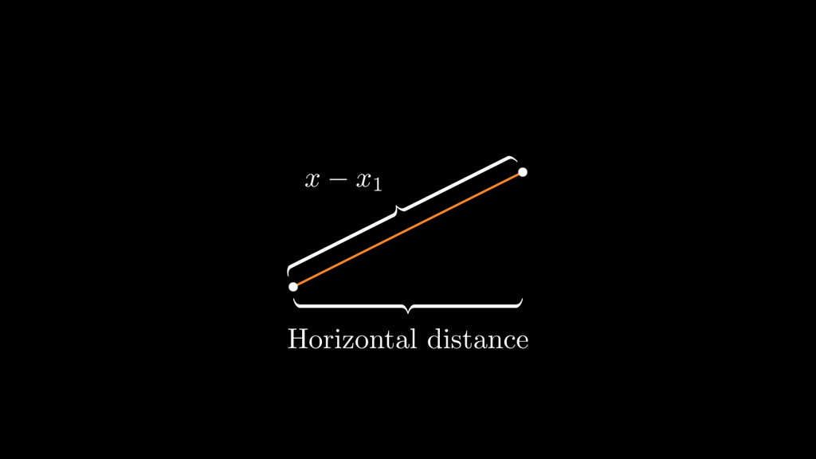

# Example 1: Points on a line

Breaking this down

Creating a class, a definition, and two `Dot`s.

```
class BraceAnnotation(Scene):
    def construct(self):
        dot = Dot([-2, -1, 0])
        dot2 = Dot([2, 1, 0])
```

Adding a `Line` Mobject which extends from the `get_center()` of one `Dot` to the next.

We set the `color` of the line to `ORANGE` as a second porperty after the `Line` is defined.

```
        line = Line(dot.get_center(), dot2.get_center()).set_color(ORANGE)
```

We add a curly `Brace` alongside the x-axis of the `Line` object `line`, and name the brace `b1`.

We also add, in a second line of code, text to accompany the brace with `get_text`.

```
        b1 = Brace(line)
        b1text = b1.get_text("Horizontal distance")
```

We do the same thing with a second brace Mobject, but this time make sure `rotate` the brace to be parallel to the line (notice how we start with the direction of the line, but then rotate it 90 degrees with `.rotate(PI/2)`.)

Instead of adding text, we add LaTeX output, `x-x_1`, or $x-x_1$.

Finally, we `self.add` to draw everything

```
        b2 = Brace(line, direction=line.copy().rotate(PI / 2).get_unit_vector())
        b2text = b2.get_tex("x-x_1")
        self.add(line, dot, dot2, b1, b2, b1text, b2text)
```

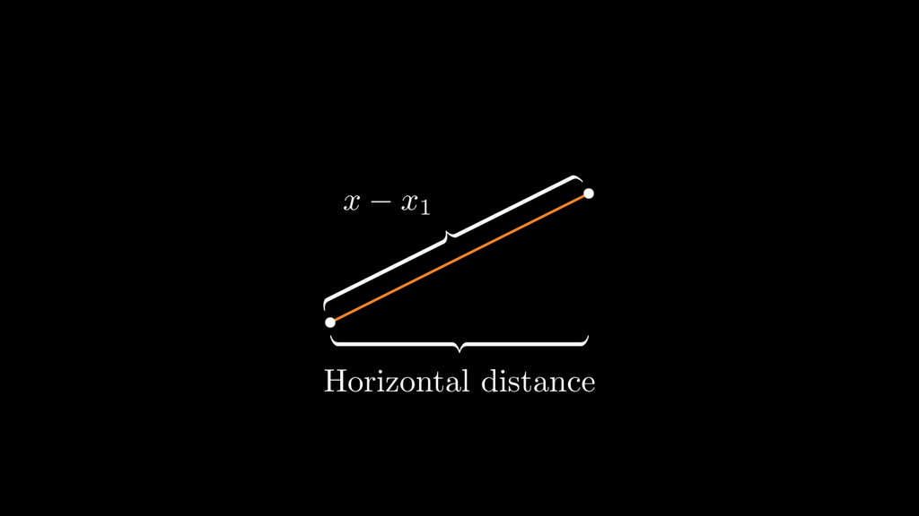

# Example 2: Logo

The Manim logo can be made *programmatically*. Let’s try it.

```
from manim import *

class ManimCELogo(Scene):
    def construct(self):
        self.camera.background_color = "#ece6e2"
        logo_green = "#87c2a5"
        logo_blue = "#525893"
        logo_red = "#e07a5f"
        logo_black = "#343434"
        ds_m = MathTex(r"\mathbb{M}", fill_color=logo_black).scale(7)
        ds_m.shift(2.25 * LEFT + 1.5 * UP)
        circle = Circle(color=logo_green, fill_opacity=1).shift(LEFT)
        square = Square(color=logo_blue, fill_opacity=1).shift(UP)
        triangle = Triangle(color=logo_red, fill_opacity=1).shift(RIGHT)
        logo = VGroup(triangle, square, circle, ds_m)  # order matters
        logo.move_to(ORIGIN)
        self.add(logo)
```

[figure not shown]

# Example 2: Logo

Let’s break it down.

The usual setup for a scene.

```
from manim import *

class ManimCELogo(Scene):
    def construct(self):
```

Set a background to cream instead of the default black.

```
        self.camera.background_color = "#ece6e2"
```

Define some variables for colours just for better code readability

```
        logo_green = "#87c2a5"
        logo_blue = "#525893"
        logo_red = "#e07a5f"
        logo_black = "#343434"
```

Define the script M.

I don’t know why there is an “r” there, I can’t tell what changes when I remove it.

That’s LaTeX for math stylized bold. `\mathbb`, scaled up to 7 times the normal text.

Shift the letter M 2.25 units left, and 1.5 units up.

```
        ds_m = MathTex(r"\mathbb{M}", fill_color=logo_black).scale(7)
        ds_m.shift(2.25 * LEFT + 1.5 * UP)
```

Define a filled-in (`fill_opacity = 1`) `Circle`, and move it one unit to the left. This could probability be done in two lines. Use the default size. Define a filled-in `Square` the same way, but move it one unit up. Use the default size. Define a filled-in `Triangle` the same way, but move it one unit right. Use the default size and orientation.

```
        circle = Circle(color=logo_green, fill_opacity=1).shift(LEFT)
        square = Square(color=logo_blue, fill_opacity=1).shift(UP)
        triangle = Triangle(color=logo_red, fill_opacity=1).shift(RIGHT)
```

Merge all four Mobjects into a single Mobject named “logo”. The first Mobject to be added is on the lowest layer, visually, just like how base R works.

We snap the logo to the point (0,0) as its center, and actually draw it with `self.add`.

```
        logo = VGroup(triangle, square, circle, ds_m)  # order matters
        logo.move_to(ORIGIN)
        self.add(logo)
```

[figure not shown]

# Example 3: Camera

```
class MovingCameraOnGraph(MovingCameraScene):
    def construct(self):
        self.camera.frame.save_state()

        ax = Axes(x_range=[-1, 10], y_range=[-1, 10])
        graph = ax.plot(lambda x: np.sin(x), color=WHITE, x_range=[0, 3 * PI])

        dot_1 = Dot(ax.i2gp(graph.t_min, graph))
        dot_2 = Dot(ax.i2gp(graph.t_max, graph))
        self.add(ax, graph, dot_1, dot_2)

        self.play(self.camera.frame.animate.scale(0.5).move_to(dot_1))
        self.play(self.camera.frame.animate.move_to(dot_2))
        self.play(Restore(self.camera.frame))
        self.wait()


%manim -qm -v WARNING MovingCameraOnGraph
```

[video not shown]

# Example 3: Camera

Let’s break this code down too…

```
class MovingCameraOnGraph(MovingCameraScene):
    def construct(self):
        self.camera.frame.save_state()

        ax = Axes(x_range=[-1, 10], y_range=[-1, 10])
        graph = ax.plot(lambda x: np.sin(x), color=WHITE, x_range=[0, 3 * PI])

        dot_1 = Dot(ax.i2gp(graph.t_min, graph))
        dot_2 = Dot(ax.i2gp(graph.t_max, graph))
        self.add(ax, graph, dot_1, dot_2)

        self.play(self.camera.frame.animate.scale(0.5).move_to(dot_1))
        self.play(self.camera.frame.animate.move_to(dot_2))
        self.play(Restore(self.camera.frame))
        self.wait()


%manim -qm -v WARNING MovingCameraOnGraph
```

Instead of making a static scene, here we’re creating a `MovingCameraScene` instead.

Part of the scene’s construction is a `camera` object, which we can manipulate with future code.

```
class MovingCameraOnGraph(MovingCameraScene):
    def construct(self):
        self.camera.frame.save_state()
```

We’ll define x- and y-axes from -1 to 10 using all the default parameters. We’ll name this set of axes `ax`.

Snapped to the axes Mobject `ax`, we can plot curve from 0 to $3\pi$ and have it follow a sine wave using the the numpy function `np.sin(x)`. We will name this curve `graph`.

We will also snap two `Dot` Mobjects to the axes as well, setting one of them at the point where $t=0$ on the curve `graph` using `graph.t_min`. We snap the other `Dot` Mobject to the point on the curve `graph` where $t = 3\pi$ using `graph.t_max`.

We’ll draw all these Mobjects onto the Scene with `self.add`.

```
        ax = Axes(x_range=[-1, 10], y_range=[-1, 10])
        graph = ax.plot(lambda x: np.sin(x), color=WHITE, x_range=[0, 3 * PI])

        dot_1 = Dot(ax.i2gp(graph.t_min, graph))
        dot_2 = Dot(ax.i2gp(graph.t_max, graph))
        self.add(ax, graph, dot_1, dot_2)
```

Finally, we’ll establish the animation events with `self.play` commands. In this case, the Mobjects aren’t animating, the camera is moving.

With multiple `self.play` commands, the animation will act on each command in sequence. If we want to do more than one thing at a time, we need to put them in the same `self.play` command.

`self.camera.frame.animate.scale(0.5)` zooms the camera so that the scale is 0.5 times the default, and `move_to(dot_1)` pans the camera such the centre of the screen is on the location of `dot_1`.

Notice that in this line, we need `self.camera.frame.animate` once, but we are doing two things at the same time.

```
        self.play(self.camera.frame.animate.scale(0.5).move_to(dot_1))
```

In the next line, we move the camera again but as a sequential action, so we need `self.camera.frame.animate` again.

Next, we return the camera to its default position and zoom with the `Restore` command.

Next, we want the animation to stall for 1 second on at the end with `self.wait()`

```
        self.play(self.camera.frame.animate.move_to(dot_2))
        self.play(Restore(self.camera.frame))
        self.wait()
```

And finally we have the line that makes this work in Jupyter notebook.

```
%manim -qm -v WARNING MovingCameraOnGraph
```

[video not shown]

# Example 3: Camera

This example plays around some more with the camera.

```
class MovingCameraOnGraph(MovingCameraScene):
    def construct(self):
        self.camera.frame.save_state()

        ax = Axes(x_range=[-1, 10], y_range=[-1, 10])
        graph = ax.plot(lambda x: np.sin(x), color=WHITE, x_range=[0, 3 * PI])

        dot_1 = Dot(ax.i2gp(graph.t_min, graph))
        dot_2 = Dot(ax.i2gp(graph.t_max, graph))
        self.add(ax, graph, dot_1, dot_2)

        # Invisible dot_3 because it's not in self.add
        dot_3 = Dot([1,1,0])


        # Move and scale in one step
        self.play(self.camera.frame.animate.scale(0.5).move_to(dot_1))

        # Just move
        self.play(self.camera.frame.animate.move_to(dot_2))

        # Just move, then scale
        self.play(self.camera.frame.animate.move_to(dot_3))
        self.play(self.camera.frame.animate.scale(20))

        # Return to defaults
        self.play(Restore(self.camera.frame))
        self.wait()



# don't remove below command for run button to work
%manim -qm -v WARNING MovingCameraOnGraph
```

[video not shown]

# Example 4: Graph

From: https://slama.dev/manim/camera-and-graphs/

Here we define a network of 11 nodes and 12 edges between the nodes. For example there is a connection (edge) between nodes 1 and 2, and also between nodes 5 and 11.

In the `Graph`, the visual layout of the 11 nodes (and therefore the edges) is autoconfigured with `layout_config` to reduce the number of crossovers between edges.

`Write(g)` makes the Mobject get written in as animation, instead of just popping into existence.

```
%%manim -qm -v WARNING GraphExample

class GraphExample(Scene):
    def construct(self):
        # the graph class expects a list of vertices and edges
        vertices = [1, 2, 3, 4, 5, 6, 7, 8, 9, 10, 11]
        edges = [(1, 2), (2, 3), (3, 4), (2, 4), (2, 5), (6, 5),
                 (1, 7), (5, 7), (2, 8), (1, 9), (10, 8), (5, 11)]

        # we're using the layout_config's seed parameter to deterministically set the
        # vertex positions (it is otherwise set randomly)
        g = Graph(vertices, edges, layout_config={"seed": 0}).scale(1.6)

        self.play(Write(g))

        # the graph contains updaters that align edges with their vertices
        self.play(g.vertices[6].animate.shift((LEFT + DOWN) * 0.5))
```

[video not shown]

Playing with the random seed.

```
        g = Graph(vertices, edges, layout_config={"seed": 1}).scale(1.6)
```

[video not shown]

Playing with the scale.

```
        g = Graph(vertices, edges, layout_config={"seed": 2}).scale(2.5)
```

[video not shown]

# Example 4: Graph

From: https://slama.dev/manim/camera-and-graphs/

Sl-i-i-i-i-de to the left.

```
%%manim -qm -v WARNING GraphExample

class GraphExample(Scene):
    def construct(self):
        # the graph class expects a list of vertices and edges
        vertices = [1, 2, 3, 4, 5, 6, 7, 8, 9, 10, 11]
        edges = [(1, 2), (2, 3), (3, 4), (2, 4), (2, 5), (6, 5),
                 (1, 7), (5, 7), (2, 8), (1, 9), (10, 8), (5, 11)]

        # we're using the layout_config's seed parameter to deterministically set the
        # vertex positions (it is otherwise set randomly)
        g = Graph(vertices, edges, layout_config={"seed": 0}).scale(1.6)

        self.play(Write(g))

        # the graph contains updaters that align edges with their vertices
        self.play(g.vertices[6].animate.shift((LEFT + DOWN) * 0.5))

        self.play(g.animate.shift(LEFT * 3))
```

[video not shown]

```
        # the graphs can also contain labels and be organized into specific layouts
        # (see the Graph class documentation for the list of all possible layouts)
        h = Graph(vertices, edges, labels=True, layout="circular").shift(RIGHT * 3)

        self.play(Write(h))
```

[video not shown]

[video not shown]

```
        # color the vertex 5 and all of its neighbours
        v = 5
        self.play(
            Flash(g.vertices[v], color=RED, flash_radius=0.5),
            g.vertices[v].animate.set_color(RED),
            *[g.edges[e].animate.set_color(RED) for e in g.edges if v in e],
        )
```

[video not shown]

# Example 5: LaTeX

Notice that the `MathTex` Mobject we define is actually an array of TeX codes. Also notice that we need to use `\\` instead of `\` because we need to escape the `\` in Python.

The first `self.play` writes all the text as if it were a single Mobject.

The second `self.play` makes the `SurroundingRectangle` Mobject.

The third `self.play` transforms it by moving it.

```
class MovingFrameBox(Scene):
    def construct(self):
        text=MathTex(
            "\\frac{d}{dx}f(x)g(x)=",
            "f(x)\\frac{d}{dx}g(x)","+",
            "g(x)\\frac{d}{dx}f(x)"
        )
        self.play(Write(text))
        framebox1 = SurroundingRectangle(text[1], buff = .1)
        framebox2 = SurroundingRectangle(text[3], buff = .1)
        self.play(
            Create(framebox1),
        )
        self.wait()
        self.play(
            ReplacementTransform(framebox1,framebox2),
        )
        self.wait()



# don't remove below command for run button to work
%manim -qm -v WARNING MovingFrameBox
```

[video not shown]